# ARIMAX SARIMAX VAR

### Model Selection for ARIMAX Models

#### Model 1: SPY ~ Interest Rate 1-Year + Daily Weather Property Damage + Daily VIX Change + Daily Striking Worker Total

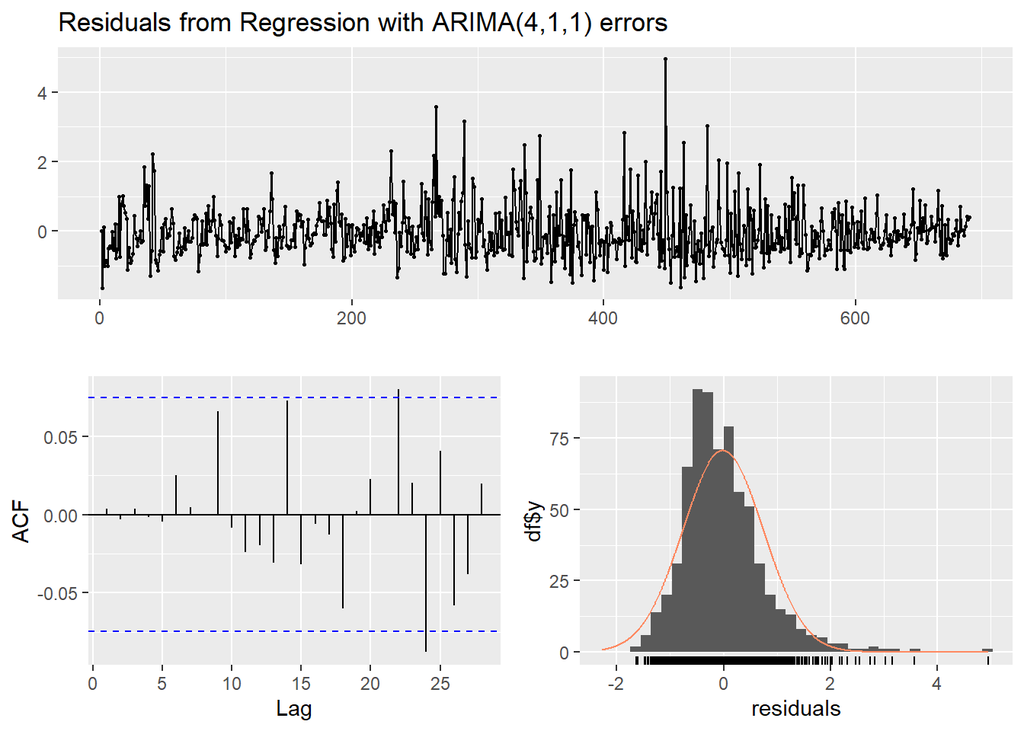

```
    Ljung-Box test

data:  Residuals from Regression with ARIMA(4,1,1) errors
Q* = 3.619, df = 5, p-value = 0.6055

Model df: 5.   Total lags used: 10
```

```r
xMatrix = combinedData[,c('mo12delta', 'pdam', 'dailyChange', 'workers')]
xMatrix[is.na(xMatrix)] <- 0
xMatrix = scale(xMatrix)
xMatrix = as.matrix(xMatrix)

#xMatrix

mod1candidate1 = auto.arima(scale(combinedData$spyRange), xreg = xMatrix, trace = FALSE)
checkresiduals(mod1candidate1)
```

Auto ARIMA picks out the model (4,1,1) for the standardized data. The residual diagnostic plots look good, with the residuals normally distributed.

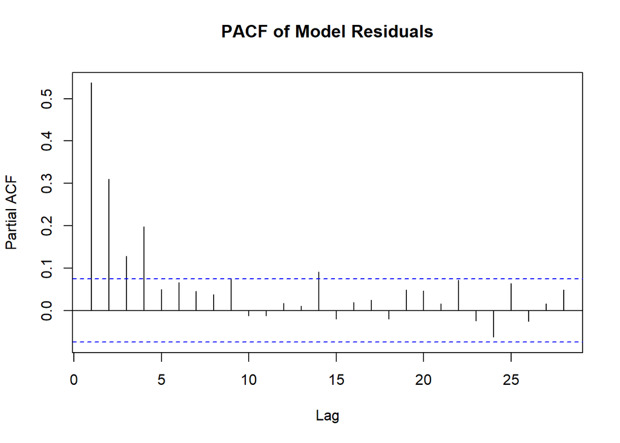

```r
xMatrix = as.data.frame(xMatrix)

# Lets examine the residuals directly to identify
mod1candidate2 <- lm(scale(combinedData$spyRange) ~ mo12delta + pdam + dailyChange + workers, data = xMatrix )
#summary(mod1candidate2)

resid1 <- mod1candidate2$residuals
pacf(resid1,main = "PACF of Model Residuals")
```

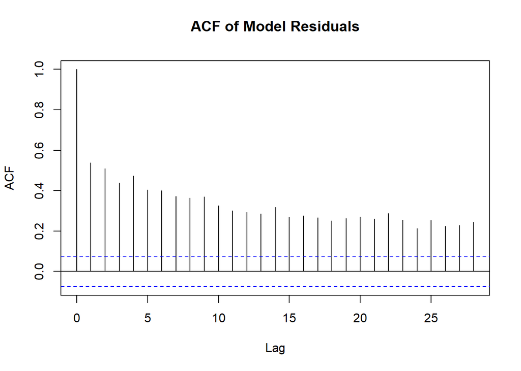

```r
acf(resid1,main = "ACF of Model Residuals")
```

Based on the PACF and ACF of the residuals from the regression, it seems we should definitely difference the series, as we have many significant lag terms in the ACF. On the PACF, we can see 4 terms clearly signfificant. Based on these charts, I might try the model (4,1,0). I will try up through (4,2,2) and look for the lowest aic.

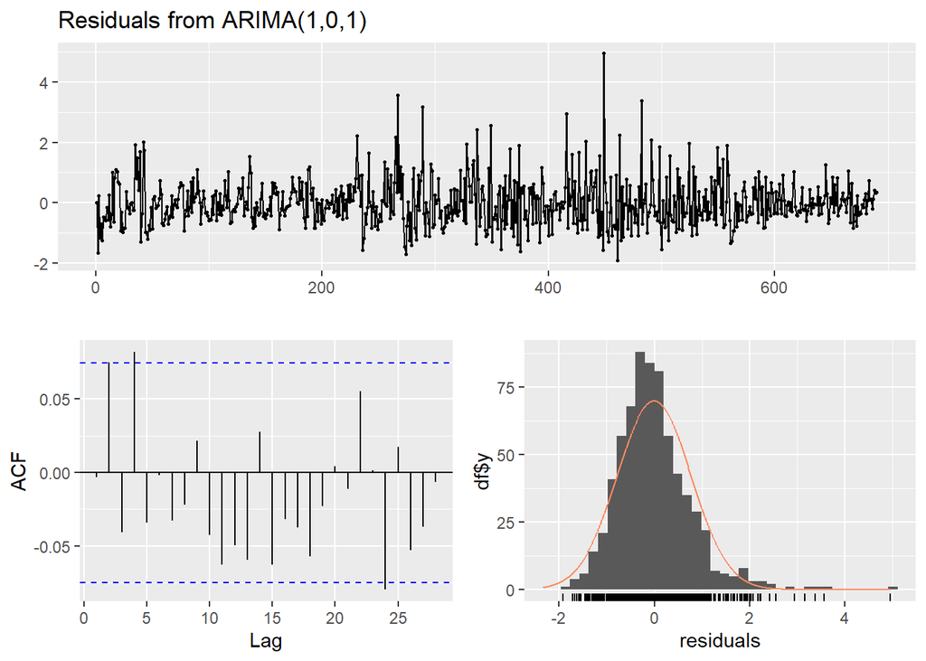

```
    Ljung-Box test

data:  Residuals from ARIMA(1,0,1)
Q* = 13.208, df = 8, p-value = 0.1049

Model df: 2.   Total lags used: 10
```

```r
SARIMA.c=function(p1,p2,q1,q2,P1,P2,Q1,Q2,d1,d2,data){

temp=c()
d=1
D=1
s=12

i=1
temp= data.frame()
ls=matrix(rep(NA,9*378),nrow=378)


for (p in p1:p2)
  {
    for(q in q1:q2)
    {
      for(P in P1:P2)
      {
        for(Q in Q1:Q2)
        {
          for(d in d1:d2)

        {
          if(p+d+q+P+D+Q<=8)
          {

            model<- Arima(data,order=c(p-1,d,q-1),seasonal=c(P-1,D,Q-1))
            ls[i,]= c(p-1,d,q-1,P-1,D,Q-1,model$aic,model$bic,model$aicc)
            i=i+1
            #print(i)

          }

        }
      }
    }

  }

  }
  temp= as.data.frame(ls)
  names(temp)= c("p","d","q","P","D","Q","AIC","BIC","AICc")

  temp

}


#SARIMA.c(p1=1,p2=5,q1=1,q2=4,P1=1,P2=3,Q1=1,Q2=2,d1=0,d2=1,data=resid1) %>% filter(!is.na(p))

mod1candidate2 <- arima(resid1, order = c(1,0,1), seasonal = list(order = c(0,1,0)))
checkresiduals(mod1candidate2)
```

#### Model 3: (ARIMAX) IWM ~ Casualties + Hurricanes + Interest Rate 3-Months

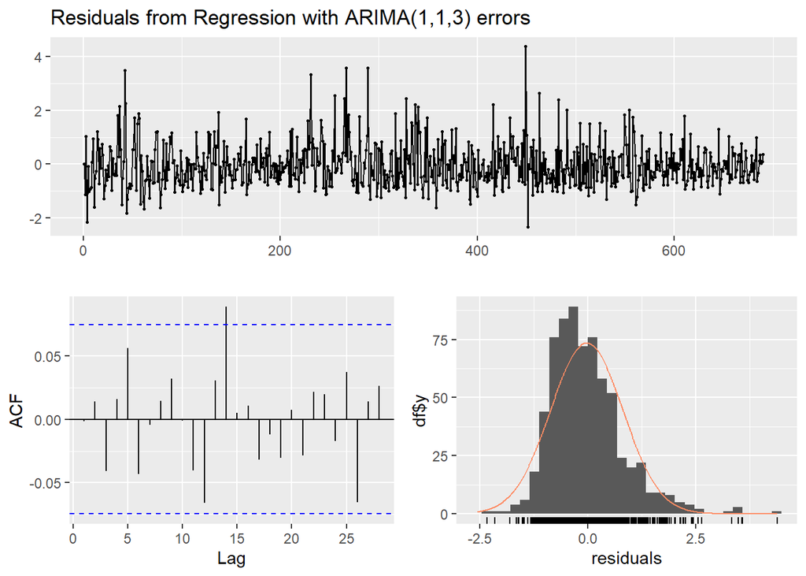

```
    Ljung-Box test

data:  Residuals from Regression with ARIMA(1,1,3) errors
Q* = 5.873, df = 6, p-value = 0.4376

Model df: 4.   Total lags used: 10
```

```r
xMatrix3 = combinedData[,c('mo3delta', 'casualties', 'hurricaneWarnings')]
xMatrix3[is.na(xMatrix3)] <- 0
xMatrix3 = scale(xMatrix3)
xMatrix3 = as.matrix(xMatrix3)

#xMatrix

mod3candidate1 = auto.arima(scale(combinedData$iwmRange), xreg = xMatrix3, trace = FALSE)
checkresiduals(mod3candidate1)
```

Auto.arima identifies (1,1,3) as the best model. The residuals show a low level of correlation in the lags, which is encouraging, and overall the residuals are mostly normally distributed although they are somewhat skewed to the right. Now, let’s see what we manually select, also considering a SARIMAX model.

Prepare residuals:

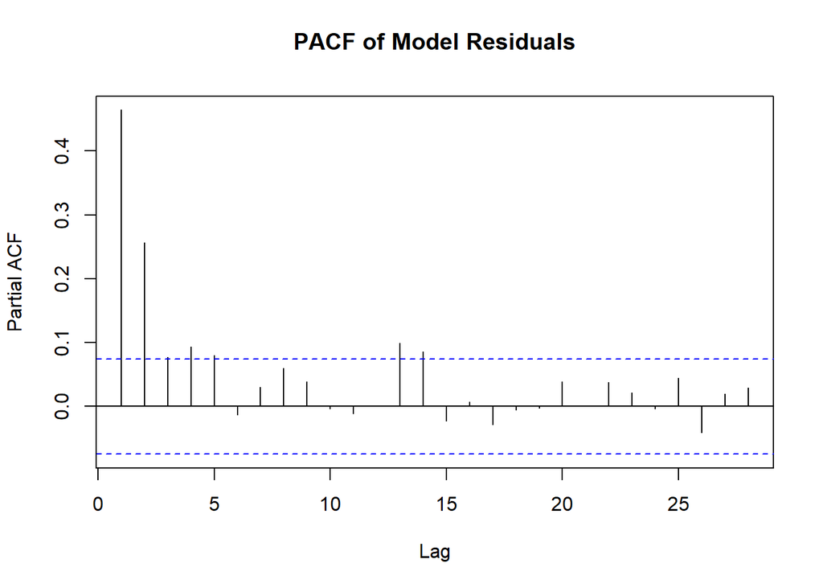

```r
xMatrix3 = as.data.frame(xMatrix3)

# Lets examine the residuals directly to identify
mod3candidate2 <- lm(scale(combinedData$iwmRange) ~ casualties + mo3delta + hurricaneWarnings, data = xMatrix3 )
#summary(mod3candidate2)

resid3 <- mod3candidate2$residuals
pacf(resid3, main = "PACF of Model Residuals")
```

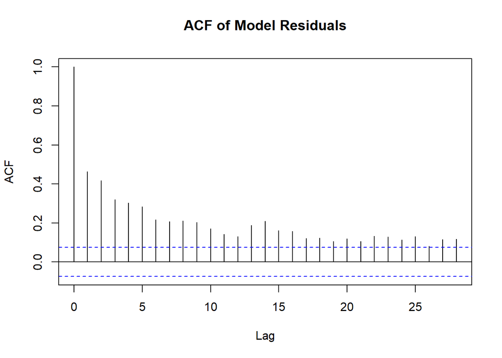

```r
acf(resid3, main = "ACF of Model Residuals")
```

The ACF and PACF plots of the residuals from linear regression are mixed, but there is clear correlation through value 5 in the PACF plot. The ACF plot has many significant terms, suggesting the series should be differenced. Now, I’ll loop through all the options to see if there is a suitable SARIMA model for the residuals:

```r
#output=SARIMA.c(p1=1,p2=3,q1=1,q2=4,P1=1,P2=3,Q1=1,Q2=2,d1=0,d2=1,data=resid3)
#output %>% filter(!is.na(p))
```

The best model identified by a small margin is SARIMA(1,0,1)(1,1,0). Let’s check the diagnostics

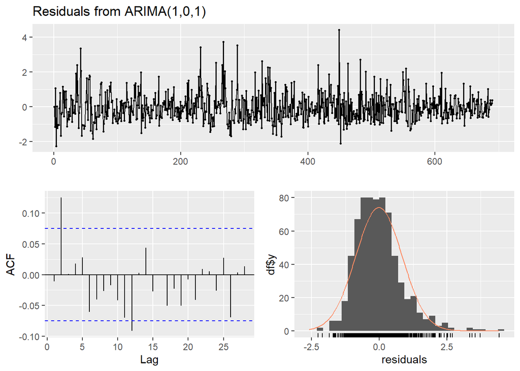

```
    Ljung-Box test

data:  Residuals from ARIMA(1,0,1)
Q* = 17.291, df = 8, p-value = 0.02722

Model df: 2.   Total lags used: 10
```

```r
residualsMod3Can2 <- arima(resid3, order = c(1,0,1), seasonal = list(order = c(1,1,0)))
checkresiduals(residualsMod3Can2)
```

The residuals for this model arent encouraging, as the Ljung Box test returns a p value of 0.03. THe residuals also do not look perfectly normally distributed.

#### Model 4: (ARIMAX) QQQ ~ All Interest Rates + All Extreme Weather Events + Daily VIX Change + Daily Striking Workers

Running an auto arima:

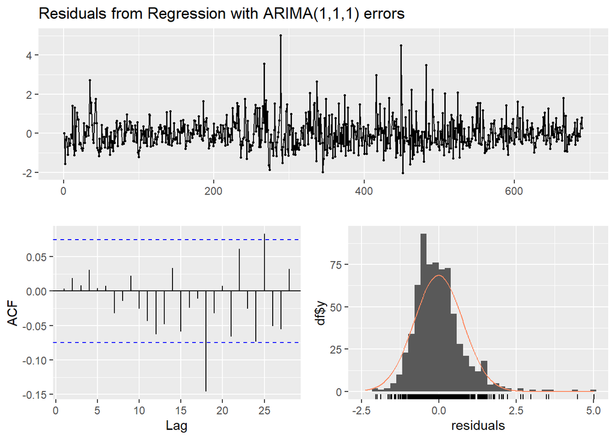

```
    Ljung-Box test

data:  Residuals from Regression with ARIMA(1,1,1) errors
Q* = 2.722, df = 8, p-value = 0.9506

Model df: 2.   Total lags used: 10
```

```r
xMatrix4 = combinedData[,c('mo3delta', 'mo6delta', 'mo12delta', 'events', 'dailyChange', 'workers')]
xMatrix4[is.na(xMatrix4)] <- 0
xMatrix4 = scale(xMatrix4)
xMatrix4 = as.matrix(xMatrix4)

#xMatrix

mod4candidate1 = auto.arima(scale(combinedData$qqqRange), xreg = xMatrix4, trace = FALSE)
checkresiduals(mod4candidate1)
```

Auto Arima returns (1,1,1). The diagnostics look acceptable, although there is clustered volatility in the residual plot. The Ljung-Box test returns p = 0.95, suggesting there is not autocorrelation in the residuals. However, the residual lag plot has high correlation around lag 20, and the correlation of the residuals slightly increases as the lags get greater.

Now let’s select a candidate manually, including from SARIMA models. First we calculate and review the residuals from the linear regression:

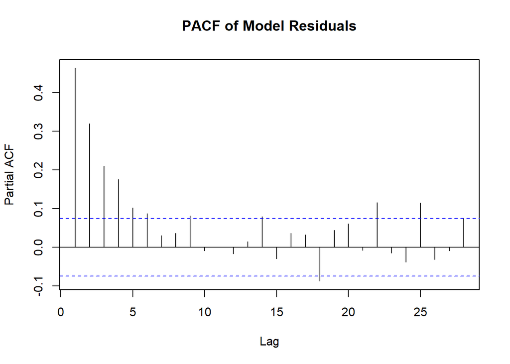

```r
xMatrix4 = as.data.frame(xMatrix4)

# Lets examine the residuals directly to identify
mod4candidate2 <- lm(scale(combinedData$qqqRange) ~ mo3delta + mo6delta + mo12delta + events + dailyChange, data = xMatrix4 )
#summary(mod1candidate2)

resid4 <- mod4candidate2$residuals
pacf(resid4, main = "PACF of Model Residuals")
```

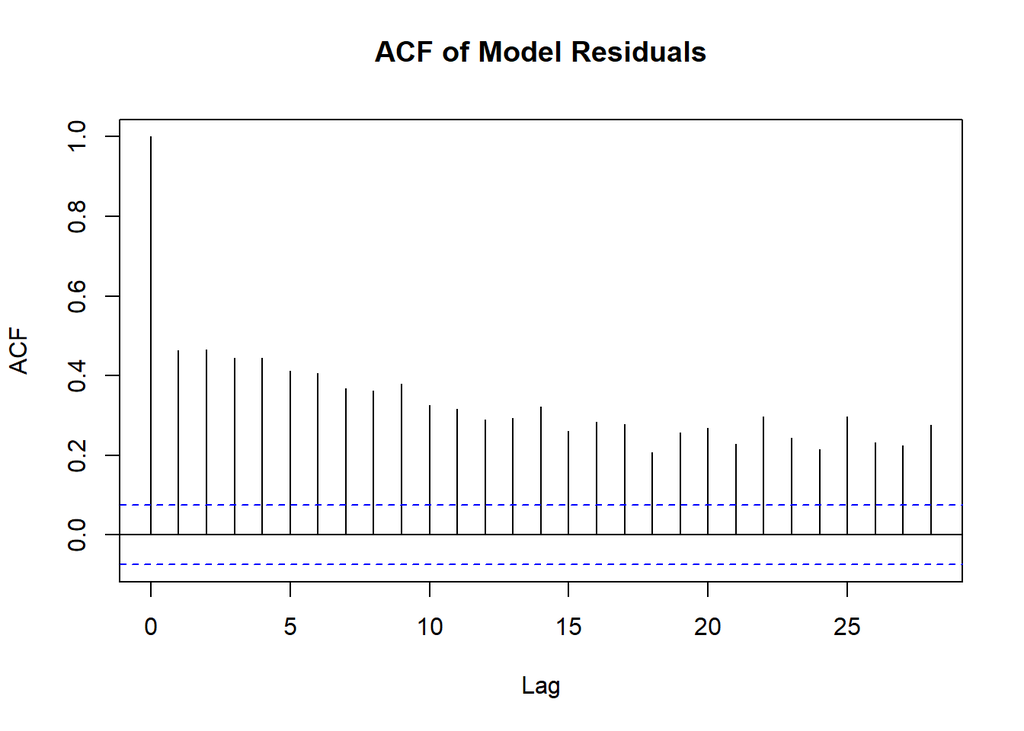

```r
acf(resid4, main = "ACF of Model Residuals")
```

The ACF plot has many significant lags (>10) which suggests we may need to difference the residuals. The PACF plot has high significance through lag 5. Let’s run a function to check all of the values up through p=2 and q=5.

```r
#mod4candidate2fit =SARIMA.c(p1=1,p2=2,q1=1,q2=5,P1=1,P2=3,Q1=1,Q2=2,d1=0,d2=1,data=resid4)
#mod4candidate2fit %>% filter(!is.na(p))
```

The best AIC and BIC scores returned by the function are for the model SARIMA(1,0,1)(1,1,0). Let’s look at the diagnostic plots to see how well this model captures the data:

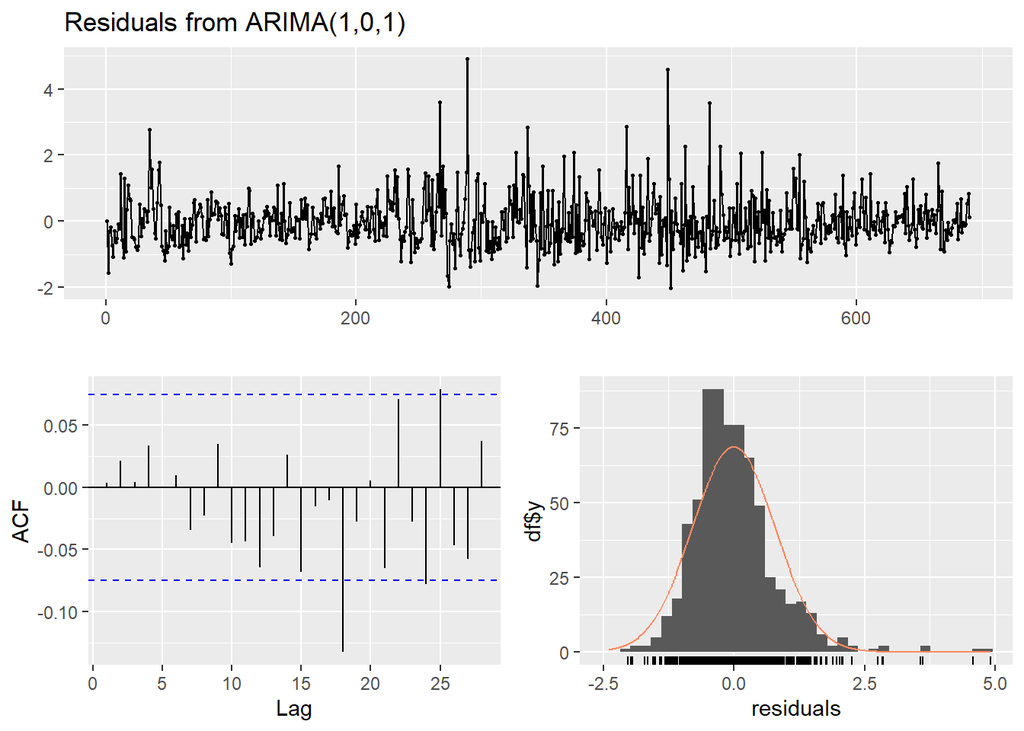

```
    Ljung-Box test

data:  Residuals from ARIMA(1,0,1)
Q* = 4.6414, df = 8, p-value = 0.7951

Model df: 2.   Total lags used: 10
```

```r
mod4candidate2fit = arima(resid4, order = c(1,0,1), seasonal = list(order = c(1,1,0)))
checkresiduals(mod4candidate2fit)
```

The residuals for this model look similar to the auto.arima model, so it will be interesting to compare them with cross validation. Otherwise, it is notable that the residuals display clustered volatility, while the lag plot shows significant correlations at some values, although the Ljung-Box test returns 0.795 so we can conclude there is no autocorrelation in the residuals.

#### Model 5: (ARIMAX) IWM ~ All Interest Rates + All Extreme Weather Events + Daily VIX Change + Daily Striking Workers

Running an auto arima:

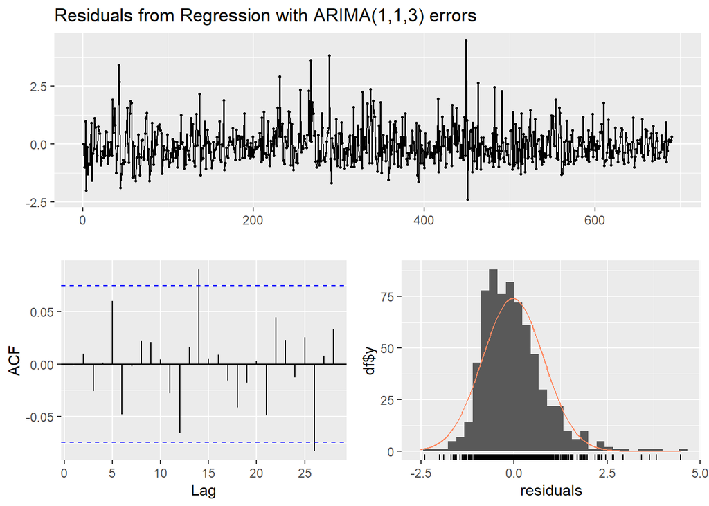

```
    Ljung-Box test

data:  Residuals from Regression with ARIMA(1,1,3) errors
Q* = 5.3537, df = 6, p-value = 0.4993

Model df: 4.   Total lags used: 10
```

```r
xMatrix5 = combinedData[,c('mo3delta', 'mo6delta', 'mo12delta', 'events', 'dailyChange', 'workers')]
xMatrix5[is.na(xMatrix4)] <- 0
xMatrix5 = scale(xMatrix4)
xMatrix5 = as.matrix(xMatrix4)

#xMatrix

mod5candidate1 = auto.arima(scale(combinedData$iwmRange), xreg = xMatrix5, trace = FALSE)
checkresiduals(mod5candidate1)
```

Auto Arima returns (1,1,3). The diagnostics look acceptable, although there is clustered volatility in the residual plot. The Ljung-Box test returns p = 0.499, suggesting there is not autocorrelation in the residuals. However, the residual lag plot has high correlation around lag 14 and 26.

Now let’s select a candidate manually, including from SARIMA models. First we calculate and review the residuals from the linear regression:

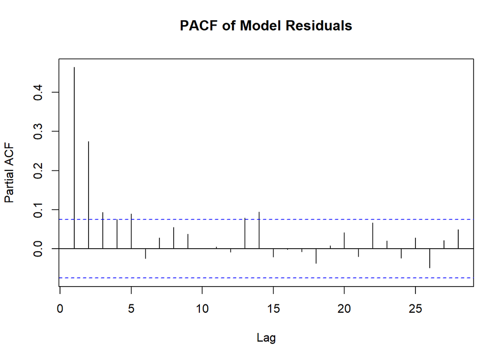

```r
xMatrix5 = as.data.frame(xMatrix5)

# Lets examine the residuals directly to identify
mod5candidate2 <- lm(scale(combinedData$iwmRange) ~ mo3delta + mo6delta + mo12delta + events + dailyChange, data = xMatrix5 )
#summary(mod5candidate2)

resid5 <- mod5candidate2$residuals
pacf(resid5,main = "PACF of Model Residuals")
```

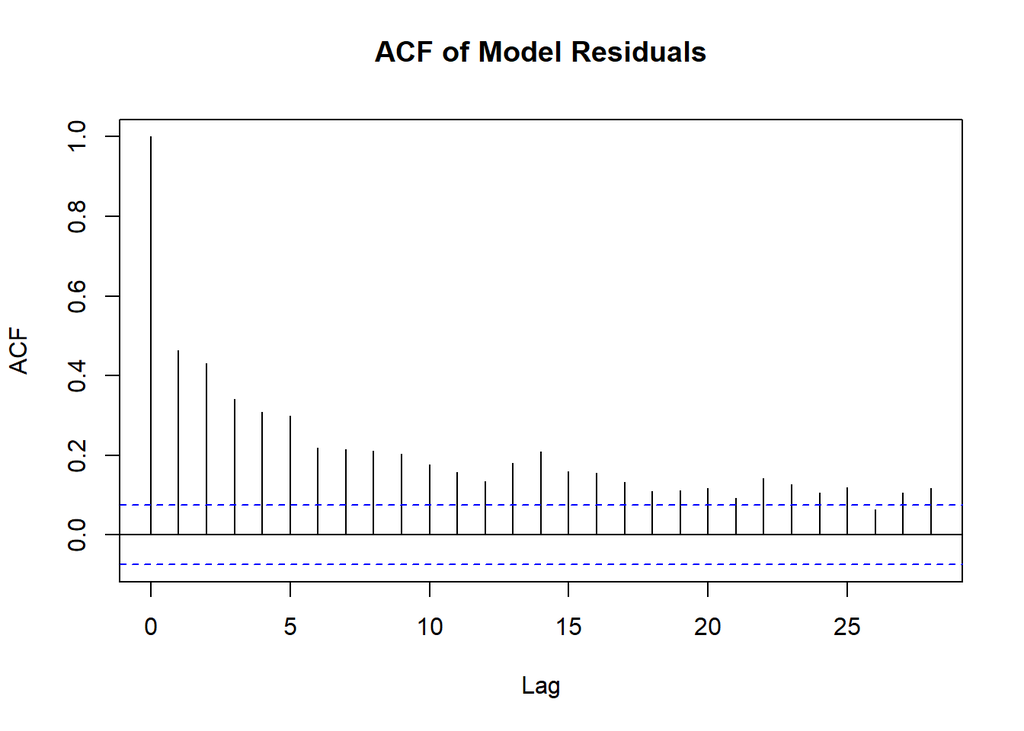

```r
acf(resid5,main = "ACF of Model Residuals")
```

The ACF plot has many significant lags (>10) which suggests we may need to difference the residuals. The PACF plot has high significance through lag 5. Let’s run a function to check all of the values up through p=2 and q=5.

```r
#mod5candidate2fit =SARIMA.c(p1=1,p2=2,q1=1,q2=5,P1=1,P2=3,Q1=1,Q2=2,d1=0,d2=1,data=resid5)
#mod5candidate2fit %>% filter(!is.na(p))
```

The best AIC and BIC scores returned by the function are for the model SARIMA(1,0,1)(1,1,0). The same as for QQQ with the same exogenous predictors. Let’s look at the diagnostic plots to see how well this model captures the data:

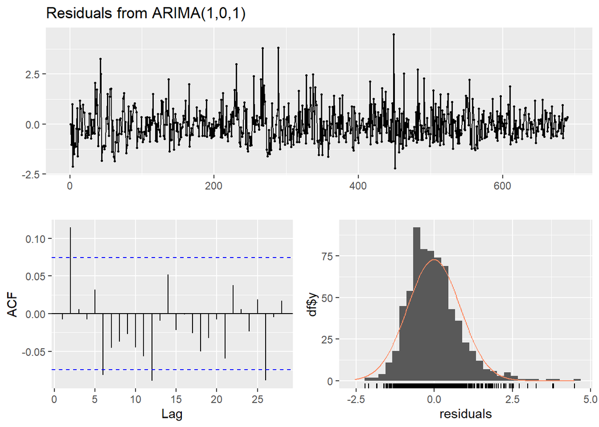

```
    Ljung-Box test

data:  Residuals from ARIMA(1,0,1)
Q* = 18.89, df = 8, p-value = 0.01546

Model df: 2.   Total lags used: 10
```

```r
mod5candidate2fit = arima(resid5, order = c(1,0,1), seasonal = list(order = c(1,1,0)))
checkresiduals(mod5candidate2fit)
```

### Model Selection for VAR Models

#### Model 2: (VAR) SPY ~ Interest Rate 3-Months + Daily VIX Value

Step 1, let’s fit VAR with p=1 just to see the relationship between our 3 variables (SPY intraday range, 3-month interest rate changes, and the real daily VIX values).

```r
xMatrix2 = combinedData[,c('VIX.Adjusted', 'mo3delta', 'spyRange') ]
xMatrix2[is.na(xMatrix2)] <- 0
xMatrix2 = scale(xMatrix2)
xMatrix2 = as.matrix(xMatrix2)

#xMatrix

summary(vars::VAR(xMatrix2, p = 1, type = 'both'))
```

```
VAR Estimation Results:
=========================
Endogenous variables: VIX.Adjusted, mo3delta, spyRange
Deterministic variables: both
Sample size: 689
Log Likelihood: -1891.17
Roots of the characteristic polynomial:
0.9396 0.05755 0.05755
Call:
vars::VAR(y = xMatrix2, p = 1, type = "both")


Estimation results for equation VIX.Adjusted:
=============================================
VIX.Adjusted = VIX.Adjusted.l1 + mo3delta.l1 + spyRange.l1 + const + trend

                  Estimate Std. Error t value Pr(>|t|)
VIX.Adjusted.l1  9.330e-01  1.915e-02  48.710   <2e-16 ***
mo3delta.l1     -2.685e-02  1.301e-02  -2.064   0.0394 *
spyRange.l1      4.189e-03  1.888e-02   0.222   0.8245
const            1.716e-02  2.680e-02   0.641   0.5221
trend           -5.707e-05  6.794e-05  -0.840   0.4013
---
Signif. codes:  0 '***' 0.001 '**' 0.01 '*' 0.05 '.' 0.1 ' ' 1


Residual standard error: 0.3372 on 684 degrees of freedom
Multiple R-Squared: 0.8869, Adjusted R-squared: 0.8862
F-statistic:  1341 on 4 and 684 DF,  p-value: < 2.2e-16


Estimation results for equation mo3delta:
=========================================
mo3delta = VIX.Adjusted.l1 + mo3delta.l1 + spyRange.l1 + const + trend

                  Estimate Std. Error t value Pr(>|t|)
VIX.Adjusted.l1 -0.0429432  0.0558806  -0.768  0.44247
mo3delta.l1     -0.1137505  0.0379419  -2.998  0.00282 **
spyRange.l1     -0.1245585  0.0550961  -2.261  0.02409 *
const            0.1330199  0.0781812   1.701  0.08932 .
```

[output cut: 26 more lines]

```
F-statistic: 168.3 on 4 and 684 DF,  p-value: < 2.2e-16



Covariance matrix of residuals:
             VIX.Adjusted  mo3delta spyRange
VIX.Adjusted      0.11371 -0.019172 0.076451
mo3delta         -0.01917  0.967841 0.006324
spyRange          0.07645  0.006324 0.504715

Correlation matrix of residuals:
             VIX.Adjusted  mo3delta spyRange
VIX.Adjusted      1.00000 -0.057792 0.319129
mo3delta         -0.05779  1.000000 0.009049
spyRange          0.31913  0.009049 1.000000
```

Now lets use VAR select to identify some preferrable p values.

```r
vars::VARselect(xMatrix2, lag.max = 10, type = 'both')
```

```
$selection
AIC(n)  HQ(n)  SC(n) FPE(n)
     5      1      1      5

$criteria
                 1           2           3          4           5           6
AIC(n) -2.95967636 -2.96412325 -2.96215454 -2.9562924 -3.00144103 -2.99099019
HQ(n)  -2.92106481 -2.90234476 -2.87720911 -2.8481801 -2.87016173 -2.83654396
SC(n)  -2.85992432 -2.80451997 -2.74270003 -2.6769867 -2.66228407 -2.59198201
FPE(n)  0.05183573  0.05160586  0.05170783  0.0520123  0.04971693  0.05024022
                 7           8           9          10
AIC(n) -2.98502423 -2.96721214 -2.95685167 -2.95666268
HQ(n)  -2.80741107 -2.76643204 -2.73290464 -2.70954871
SC(n)  -2.52616482 -2.44850150 -2.37828980 -2.31824958
FPE(n)  0.05054219  0.05145229  0.05199039  0.05200299
```

VAR select returns either p =5 or p = 1 as the best fits, with AIC and FPE selecting p=5, and HQ and SC selecting p =1. We will use cross validation to compare these options.

## Model Evaluation

In this section, I will use cross validation to select the best candidate model for each of the 5 overaching model designs. First, lets define a cross validation function

```r
#######

crossVal <- function(arima1order, arima2order, sarima2order, data) {

    # window is always 1
    test <- 30
    trainnum <- length(data) - test
    rmse1 <- vector(mode = 'numeric', length = 30)
    rmse2 <- vector(mode = 'numeric', length = 30)

    for(i in 1:30) {
        #print(trainnum + ((i-1) * 4))
        #print(trainnum + (i*4))
        #print(trainnum + ((i-1) * 4) +1)

        xtrain <- data[c(1:(trainnum + i - 1))]
        xtest <-  data[c((trainnum+1):(trainnum+i+1))]



        ######## first Model ############
        fit <- arima(xtrain, order = arima1order)
        fcast <- predict(fit, n.ahead = 1)$pred[1]


        ######## second model ###########
        fit2 <- arima(xtrain, order = arima2order, seasonal = sarima2order)
        fcast2 <- predict(fit2, n.ahead = 1)$pred[1]

        # Errors

        rmse1[i]  <-sqrt((fcast-xtest[1])^2)
        rmse2[i]  <-sqrt((fcast2-xtest[1])^2)

    }

    outputs = data.frame("rmse1" = rmse1, 'rmse2' = rmse2)
    return(outputs)

}
```

### Model 1 (ARIMAX)

Lets test the function out on the first model, comparing ARIMA(4,1,1) vs. SARIMA(1,0,1)(0,1,0) on the residuals of the linear regression.

```r
model1comparison = crossVal(c(4,1,1), c(1,0,1), list(order = c(0,1,0)), resid1)

mean(model1comparison$rmse1)
```

```
[1] 0.2690243
```

```r
mean(model1comparison$rmse2)
```

```
[1] 0.2696219
```

Between the two models, model 1, selected by auto.arima, beats out the sarima model with a mean RMSE of 0.2690 vs. 0.2696. However, the models do perform similarly to eachother. Let’s look at a graph to make the difference more clear:

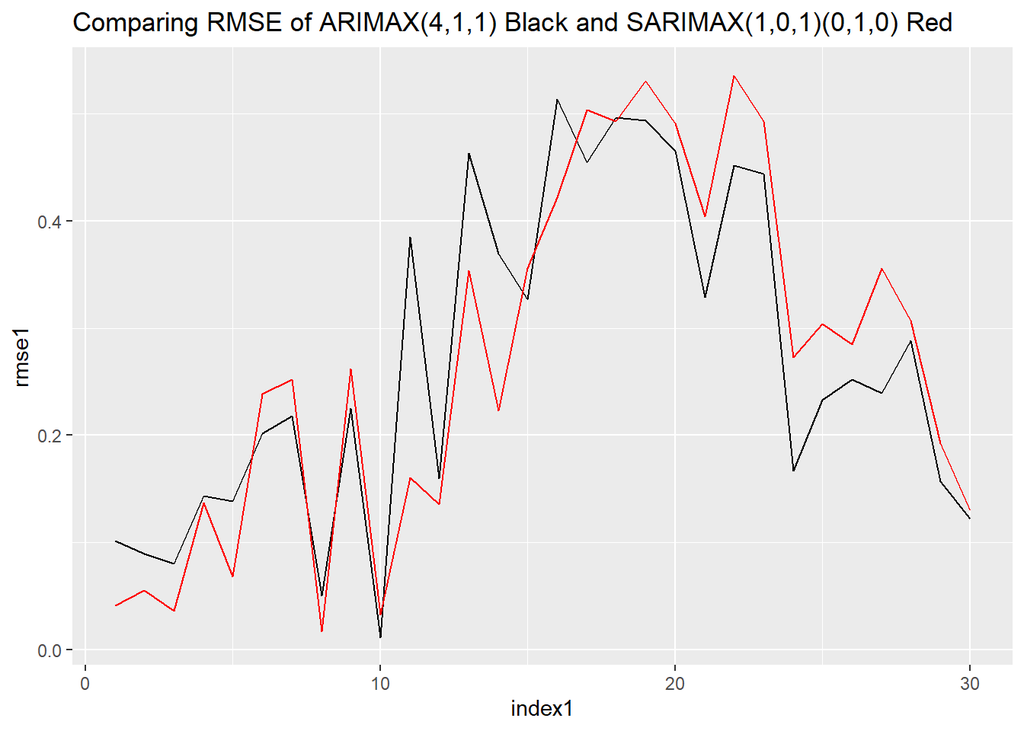

```r
index1 = c(1:nrow(model1comparison))
ggplot(data = model1comparison, aes(x = index1, y = rmse1), color = 'blue') + geom_line() + geom_line(aes(x = index1, y = rmse2), color = 'red') + labs(title = 'Comparing RMSE of ARIMAX(4,1,1) Black and SARIMAX(1,0,1)(0,1,0) Red')
```

As we can see in the cross-validation chart, the two models perform similarly, and tend to have higher and lower errors at the same time, with both of the models performing poorly near the middle of the cross validation data sets. But overall, the ARIMA (ARIMAX) model performs the best at predicting the residuals. As such, my chosen model for Model 1 is ARIMAX(4,1,1).

#### Predictions

Now, let’s make predictions:

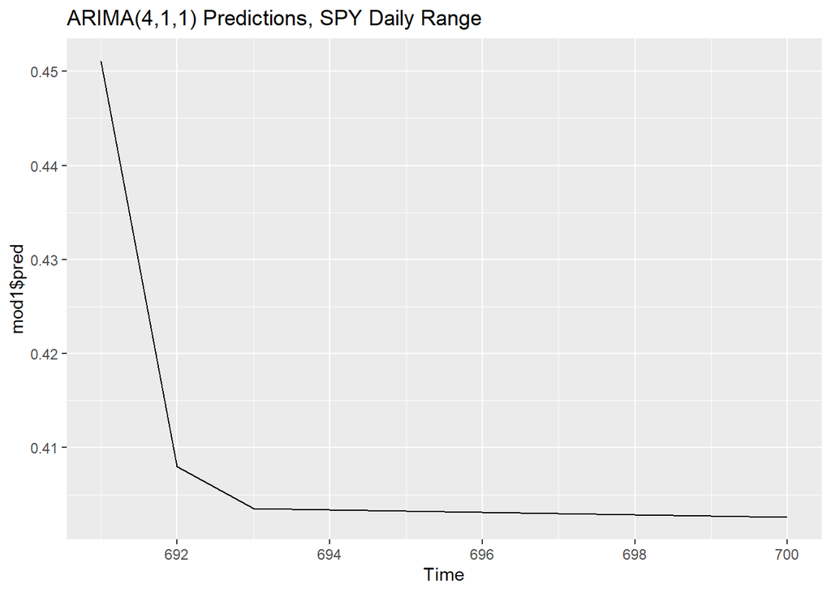

```r
#mod1candidate2 <- lm(scale(combinedData$spyRange) ~ mo12delta + pdam + dailyChange + workers, data = xMatrix )


mod1pdam <- forecast(auto.arima(combinedData$pdam), 10)
mod1delta12 <- forecast(auto.arima(combinedData$mo12delta), 10)
mod1dailyChange <- forecast(auto.arima(combinedData$dailyChange), 10)
mod1workers <- forecast(auto.arima(combinedData$workers), 10)

predictors1 <- data.frame(cbind(pdam = mod1pdam$mean, mo12delta = mod1delta12$mean, dailyChange = mod1dailyChange$mean, workers = mod1workers$mean))

fit = arima(combinedData$spyRange, order = c(4,1,1), xreg = xMatrix)

#summary(fit)
#forecast(fit)
mod1 = predict(fit, newxreg = predictors1)

autoplot(mod1$pred, main = "ARIMA(4,1,1) Predictions, SPY Daily Range")
```

Here we can see the models predictions for the SPY daily upcoming range, using auto.arima generated models to predict the external regressors. Overall, the model predicts a precipitous drop in the daily range in SPY prices in the upcoming 10 days.

### Model 2 VAR

Let’s forecast our VAR model, which used 3-month interest rate changes and daily VIX values to predict SPY’s intraday range. For this model we wanted to compare the p values of 1 and 5 to find the best model.

Lets, run our CV function:

```r
data = xMatrix2

    # window is always 1
    test <- 30
    trainnum <- nrow(data) - test
    rmse1 <- matrix(NA, 30,3)
    rmse1 <- data.frame(rmse1)
    rmse2 <- matrix(NA, 30,3)
    rmse2 <- data.frame(rmse2)

    for(i in 1:29) {

        xtrain <- data[c(1:(trainnum + i - 1)),]
        xtest <-  data[c((trainnum+i):(trainnum+i+1)),]



        ######## first Model ############
        fit <- vars::VAR(xtrain, p = 1, type = 'both')

        fcast <- predict(fit, n.ahead = 1)$fcst

        ff<-data.frame(fcast$VIX.Adjusted[,1],fcast$mo3delta[,1],fcast$spyRange[,1])

        ######## second model ###########
        fit2 <- vars::VAR(xtrain,p =5, type = 'both')
        fcast2 <- predict(fit2, n.ahead = 1)$fcst

        ff2<-data.frame(fcast2$VIX.Adjusted[,1],fcast2$mo3delta[,1],fcast2$spyRange[,1])

        # Errors

        rmse1[i,]  = sqrt((ff-xtest)^2)
        rmse2[i,]  = sqrt((ff2-xtest)^2)

    }


#print(rmse1)


names(rmse1) =c("VIXPrice", "3mo","SPYDailyRange")
names(rmse2) =c("VIXPrice", "3mo","SPYDailyRange")

colMeans(rmse1, na.rm = TRUE)
```

```
     VIXPrice           3mo SPYDailyRange
    0.1477893     1.1090823     0.6958689
```

```r
colMeans(rmse2, na.rm = TRUE)
```

```
     VIXPrice           3mo SPYDailyRange
    0.1387773     1.1899464     0.6822915
```

Overall, the p=1 VAR model was better at predicting the interest rate changes variable, and the p=5 VAR model performed better on the VIX Price and SPY daily range variables.

Let’s plot their performance:

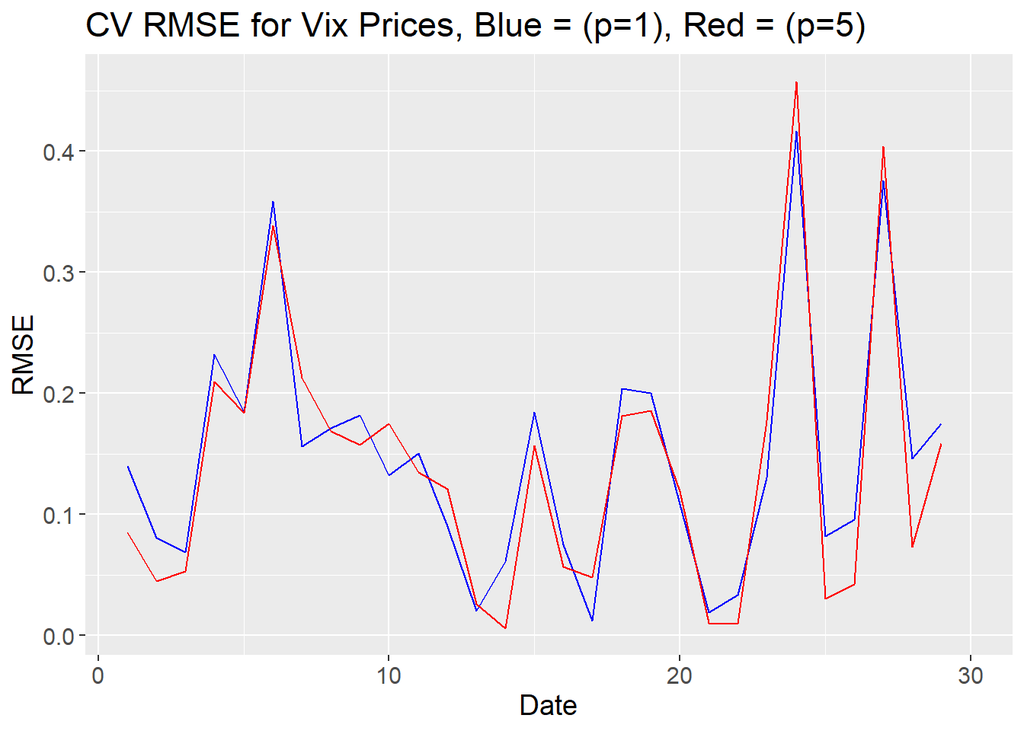

```r
index2 = c(1:nrow(rmse1))

ggplot() +
  geom_line(data = rmse1, aes(x = index2, y = VIXPrice),color = "blue") +
  geom_line(data = rmse2, aes(x = index2, y = VIXPrice),color = "red") +
  labs(
    title = "CV RMSE for Vix Prices, Blue = (p=1), Red = (p=5)",
    x = "Date",
    y = "RMSE",
    guides(colour=guide_legend(title="Fit"))) +  theme(text = element_text(size=14))
```

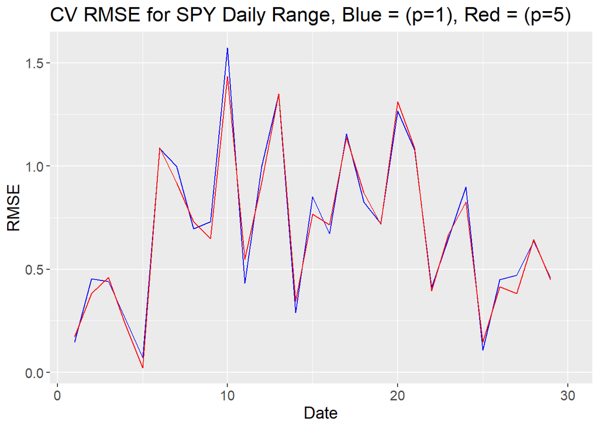

```r
ggplot() +
  geom_line(data = rmse1, aes(x = index2, y = SPYDailyRange),color = "blue") +
  geom_line(data = rmse2, aes(x = index2, y = SPYDailyRange),color = "red") +
  labs(
    title = "CV RMSE for SPY Daily Range, Blue = (p=1), Red = (p=5)",
    x = "Date",
    y = "RMSE",
    guides(colour=guide_legend(title="Fit"))) +  theme(text = element_text(size=14))
```

Overall, the charts show what we confirmed with the average values: That the mean performance of the p=5 model was better on average.

Now let’s predict:

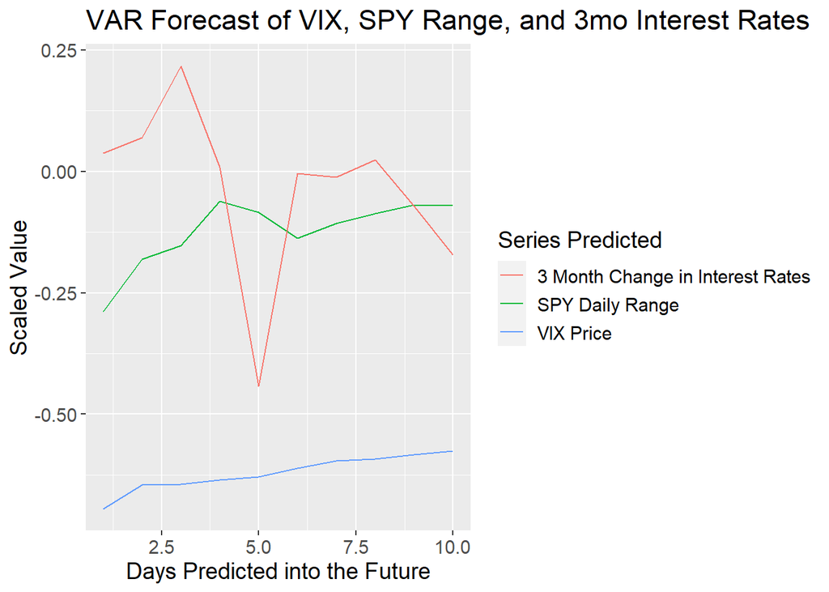

```r
finalmod2 = vars::VAR(xMatrix2, p = 5, type = 'both')

mod2forecast <- predict(finalmod2, n.ahead = 10)$fcst

indexmod2 = c(1:10)
ggplot() +
    geom_line(aes(x = indexmod2, y = mod2forecast$spyRange[1:10],color = "SPY Daily Range")) +
    geom_line(aes(x = indexmod2, y = mod2forecast$mo3delta[1:10],color = "3 Month Change in Interest Rates")) +
    geom_line(aes(x = indexmod2, y = mod2forecast$VIX.Adjusted[1:10],color = "VIX Price")) + labs(y = "Scaled Value", x = "Days Predicted into the Future", color = "Series Predicted", title = "VAR Forecast of VIX, SPY Range, and 3mo Interest Rates") +  theme(text = element_text(size=14))
```

Here we can see the scale forecasts for the 3 key variables, which are created with the predict function for the VAR model with p=5. Overall, the model predicts the SPY range to raise slightly for the next 10 days, and the 3 month interest rates to change sharply.

### Model 3 (ARIMAX) IWM ~ Casualties + Hurricanes + Interest Rate 3-Months

Let’s compare the model returned by auto.arima, ARIMA(1,1,3), vs the model I found by hand, SARIMA(1,0,1)(1,1,0), on the residuals of the linear regression for model 3.

```r
model3comparison = crossVal(c(1,1,3), c(1,0,1), list(order = c(1,1,0)), resid3)

mean(model3comparison$rmse1)
```

```
[1] 0.5537179
```

```r
mean(model3comparison$rmse2)
```

```
[1] 0.6006214
```

Once again, the simple ARIMA model beats out the SARIMA architecture in terms of average RMSE. The average for ARIMA(1,1,3) was 0.554, while for SARIMA(1,0,1)(1,1,0) it was 0.601. Let’s look at a plot of the rmse values to see how the models fared:

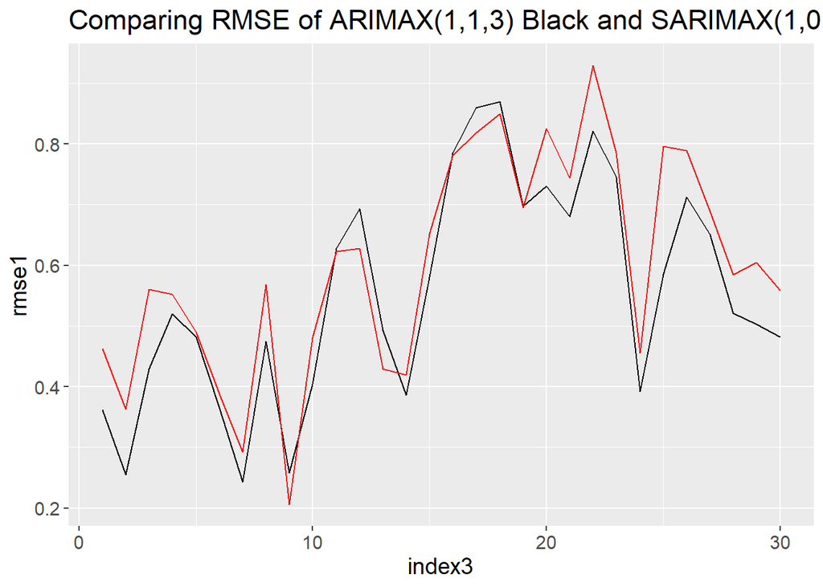

```r
index3 = c(1:nrow(model3comparison))
ggplot(data = model3comparison, aes(x = index3, y = rmse1), color = 'blue') + geom_line() + geom_line(aes(x = index3, y = rmse2), color = 'red') + labs(title = 'Comparing RMSE of ARIMAX(1,1,3) Black and SARIMAX(1,0,1)(1,1,0) Red') +  theme(text = element_text(size=14))
```

Just like for model 1, the two approaches performed similarly. If one model had a high RMSE for a particular value, the other model was likely to perform poorly as well. Overall however, we can see that for a given value the black line (ARIMA) tended to perform better. In the end, the ARIMAX models seems to fit the data well. As such, my chosen model for Model 3 is: ARIMAX(1,1,3)/.

#### Predictions

Now, let’s make predictions:

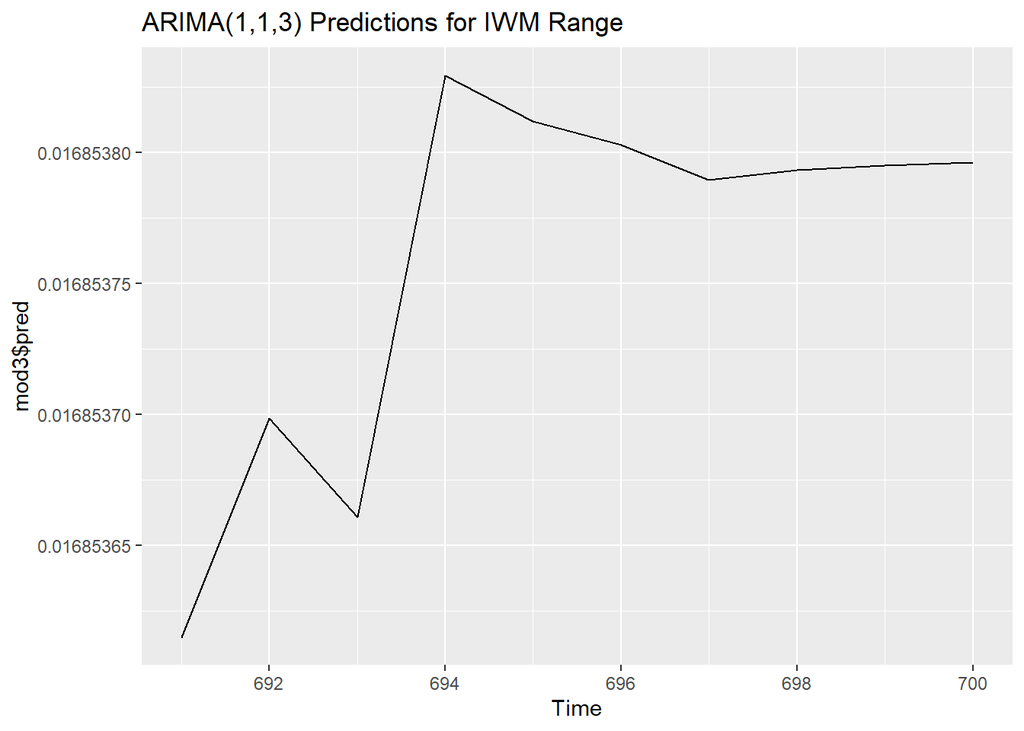

```r
#xMatrix3 = combinedData[,c('mo3delta', 'casualties', 'hurricaneWarnings')]

mod3cas <- forecast(auto.arima(combinedData$casualties), 10)
mod3delta3 <- forecast(auto.arima(combinedData$mo3delta), 10)
mod3hurricane <- forecast(auto.arima(combinedData$hurricaneWarnings), 10)

predictors3 <- data.frame(cbind(casualties = mod3cas$mean, mo3delta = mod3delta3$mean, hurricaneWarnings = mod3hurricane$mean))

fit3 = arima(combinedData$iwmRange, order = c(1,1,3), xreg = xMatrix3)

#summary(fit)
#forecast(fit)
mod3 = predict(fit3, newxreg = predictors3)

autoplot(mod3$pred, main = "ARIMA(1,1,3) Predictions for IWM Range")
```

Here we can see the models predictions for the IWM daily upcoming range, using auto.arima generated models to predict the external regressors. Overall, the model predicts a steep incline in IWM intraday ranges in the upcoming 10 days, especially in the first 5 before leveling off.

### Model 4 ARIMAX

Let’s compare the model returned by auto.arima, ARIMA(1,1,1), vs the model I found by hand, SARIMA(1,0,1)(1,1,0), on the residuals of the linear regression for model 4.

```r
model4comparison = crossVal(c(1,1,1), c(1,0,1), list(order = c(1,1,0)), resid4)

mean(model4comparison$rmse1)
```

```
[1] 0.1693671
```

```r
mean(model4comparison$rmse2)
```

```
[1] 0.1693451
```

Unlike the previous model, the SARIMA architecture beat out the simple ARIMA model, with RMSEs of 0.16934 and 0.16937 respectively. Let’s plot both RMSE values to see how this discrepancy emerged:

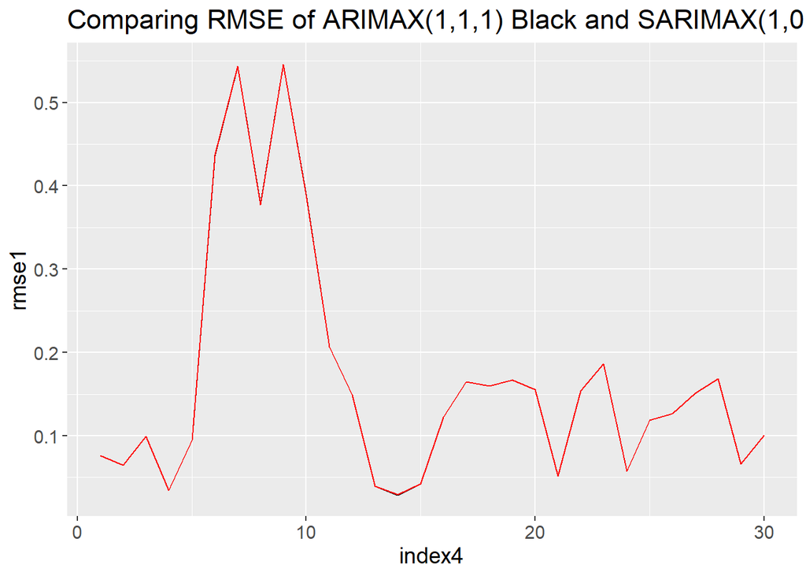

```r
index4 = c(1:nrow(model4comparison))
ggplot(data = model4comparison, aes(x = index4, y = rmse1), color = 'blue') + geom_line() + geom_line(aes(x = index4, y = rmse2), color = 'red') + labs(title = 'Comparing RMSE of ARIMAX(1,1,1) Black and SARIMAX(1,0,1)(1,1,0) Red') +  theme(text = element_text(size=14))
```

Visible in the chart above, the two models performed almost identically on the cross validation data data. Overall however, we can see that for a given value the black line (ARIMA) and the red line (SARIMAX) tended to perform almost equivalently. However, due to its slight performance edge, my chosen model for Model 4 is: SARIMAX(1,0,1)(1,1,0).

#### Predictions

Now, let’s make predictions:

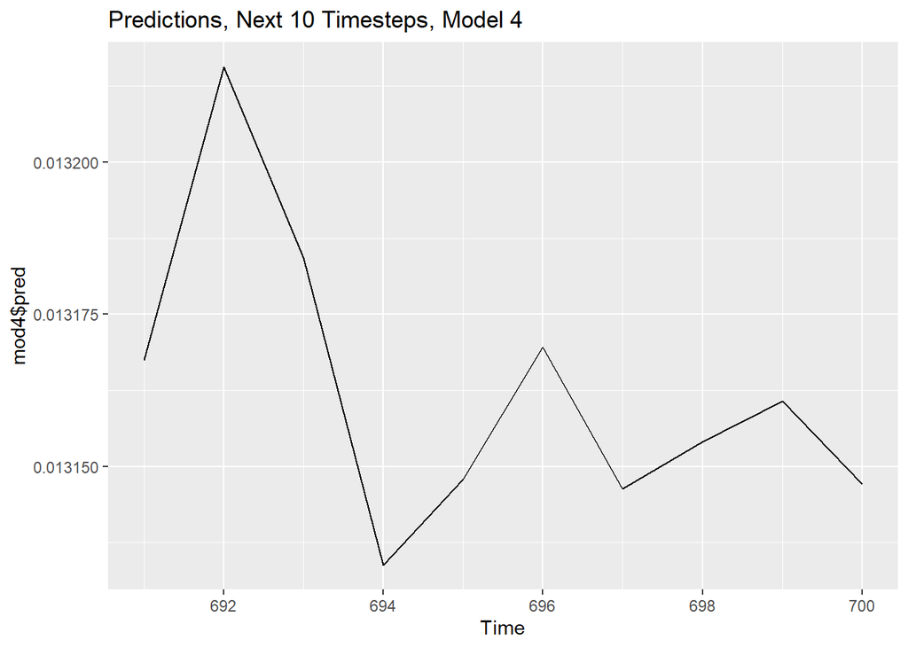

```r
xMatrix4 = combinedData[,c('events', 'mo12delta', 'mo6delta', 'mo3delta', 'dailyChange', 'workers')]

mod4events <- forecast(auto.arima(combinedData$events), 10)
mod4delta12 <- forecast(auto.arima(combinedData$mo12delta), 10)
mod4delta6 <- forecast(auto.arima(combinedData$mo6delta), 10)
mod4delta3 <- forecast(auto.arima(combinedData$mo3delta), 10)
mod4dailyChange <- forecast(auto.arima(combinedData$dailyChange), 10)
mod4workers <- forecast(auto.arima(combinedData$workers), 10)


predictors4 <- data.frame(cbind(events = mod4events$mean, mo12delta = mod4delta12$mean, mo6delta = mod4delta6$mean, mo3delta = mod4delta3$mean, dailyChange = mod4dailyChange$mean, workers = mod4workers$mean))


fit4 = arima(combinedData$qqqRange, order = c(1,0,1), seasonal = list(order = c(1,1,0)), xreg = xMatrix4)

#summary(fit)
#forecast(fit)
mod4 = predict(fit4, newxreg = predictors4)

autoplot(mod4$pred, main = "Predictions, Next 10 Timesteps, Model 4")
```

Here we can see the models predictions for the QQQ’s daily upcoming range, using auto.arima generated models to predict the external regressors. Overall, the model predicts a steep incline in QQQ intraday ranges in the upcoming several days, but then decreases again for the remained of the prediction window.

### Model 5 ARIMAX

Let’s compare the model returned by auto.arima, ARIMA(1,1,3), vs the model I found by hand, SARIMA(1,0,1)(1,1,0), on the residuals of the linear regression for model 4.

```r
model5comparison = crossVal(c(1,1,3), c(1,0,1), list(order = c(1,1,0)), resid5)

mean(model5comparison$rmse1)
```

```
[1] 0.6360297
```

```r
mean(model5comparison$rmse2)
```

```
[1] 0.6746319
```

Unlike the previous model, the simple ARIMA model performs much better than the complicated SARIMA model, with an RMSE of 0.636 that is far lower than the SARIMA’s 0.675.

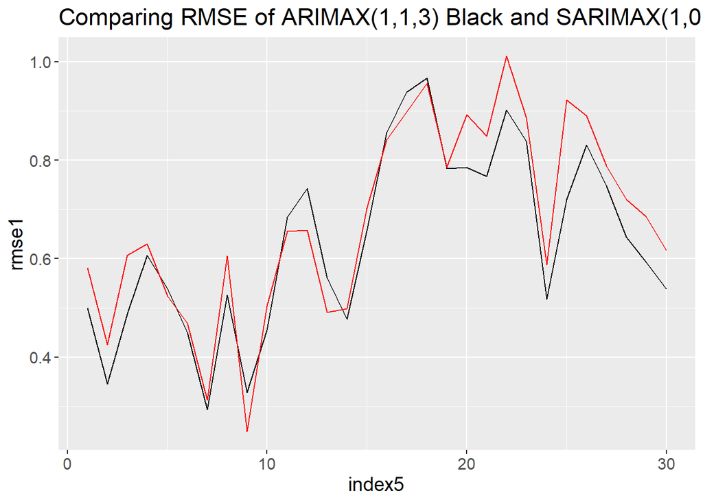

```r
index5 = c(1:nrow(model5comparison))
ggplot(data = model5comparison, aes(x = index5, y = rmse1), color = 'blue') + geom_line() + geom_line(aes(x = index5, y = rmse2), color = 'red') + labs(title = 'Comparing RMSE of ARIMAX(1,1,3) Black and SARIMAX(1,0,1)(1,1,0) Red') +  theme(text = element_text(size=14))
```

#### Predictions

Now, let’s make predictions:

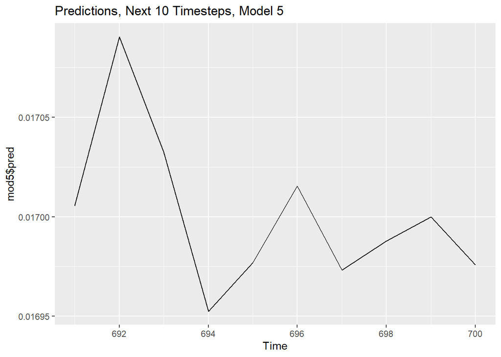

```r
xMatrix5 = combinedData[,c('events', 'mo12delta', 'mo6delta', 'mo3delta', 'dailyChange', 'workers')]

mod5events <- forecast(auto.arima(combinedData$events), 10)
mod5delta12 <- forecast(auto.arima(combinedData$mo12delta), 10)
mod5delta6 <- forecast(auto.arima(combinedData$mo6delta), 10)
mod5delta3 <- forecast(auto.arima(combinedData$mo3delta), 10)
mod5dailyChange <- forecast(auto.arima(combinedData$dailyChange), 10)
mod5workers <- forecast(auto.arima(combinedData$workers), 10)


predictors5 <- data.frame(cbind(events = mod5events$mean, mo12delta = mod5delta12$mean, mo6delta = mod5delta6$mean, mo3delta = mod5delta3$mean, dailyChange = mod5dailyChange$mean, workers = mod5workers$mean))


fit5 = arima(combinedData$iwmRange, order = c(1,1,3), xreg = xMatrix5)

#summary(fit)
#forecast(fit)
mod5 = predict(fit5, newxreg = predictors5)

autoplot(mod5$pred, main = "Predictions, Next 10 Timesteps, Model 5")
```

I will dicsuss our conclusions from these 5 models further in the conclusions page.